# Reproducible Research: Peer Assessment 1

### Loading and pre-processing the data

I created two versions of the data, one that contained NA’s and one that omitted them.

The code begins after the user has set their working directory to the folder containing the forked repo files.

```r
act<-read.csv("activity.csv")
act.na<-na.omit(act)
```

### What is the mean total number of steps taken per day?

*1. Make a histogram of the total number of steps taken each day.*

```
## stat_bin: binwidth defaulted to range/30. Use 'binwidth = x' to adjust this.
```

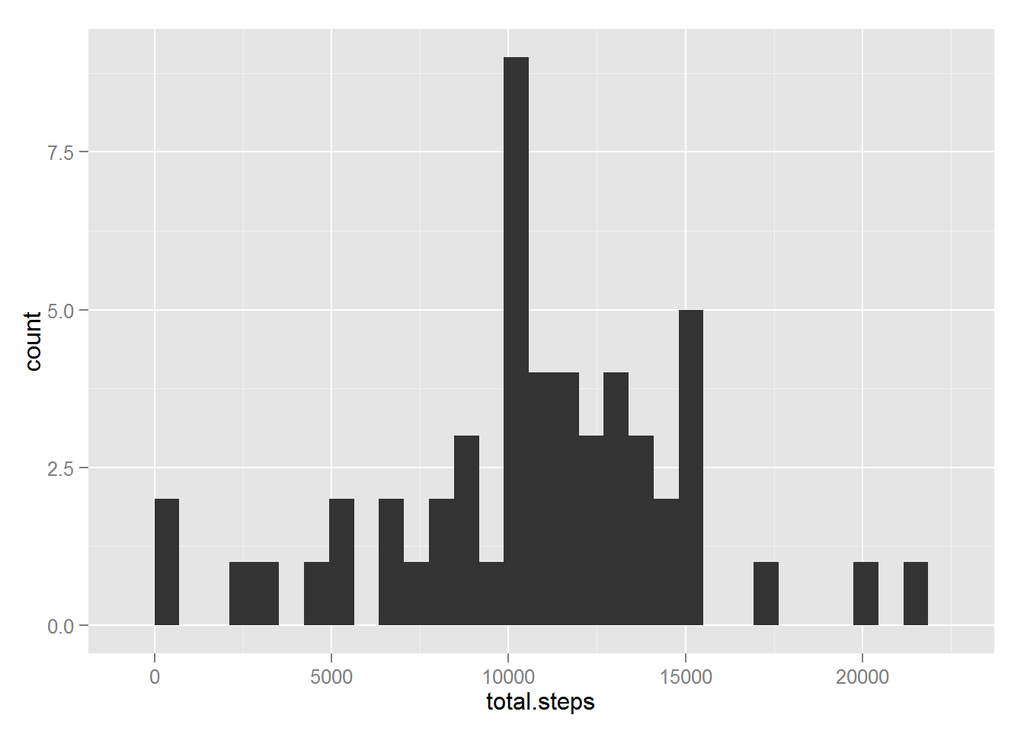

```r
library(reshape2)
totalsteps<-tapply(act.na$steps, act.na$date, sum)
totalsteps<-melt(totalsteps, id.vars="date")
names(totalsteps)<-c("date","total.steps")

library(ggplot2)
qplot(total.steps, data=totalsteps)
```

*2. Calculate and report the mean and median total number of steps taken per day.*

```r
mean(totalsteps$total.steps, na.rm=TRUE)
```

```
## [1] 10766
```

```r
median(totalsteps$total.steps,na.rm=TRUE)
```

```
## [1] 10765
```

- The mean for total number of steps taken per day (summed by day) is 10,766.19.
- The median for total number of steps taken per day (summed by day) is 10,765.
- These values are for the dataset before missing values were imputed.

### What is the average daily activity pattern?

*1. Make a time series plot of the 5-minute interval and the average number of steps taken, averaged across all days.*

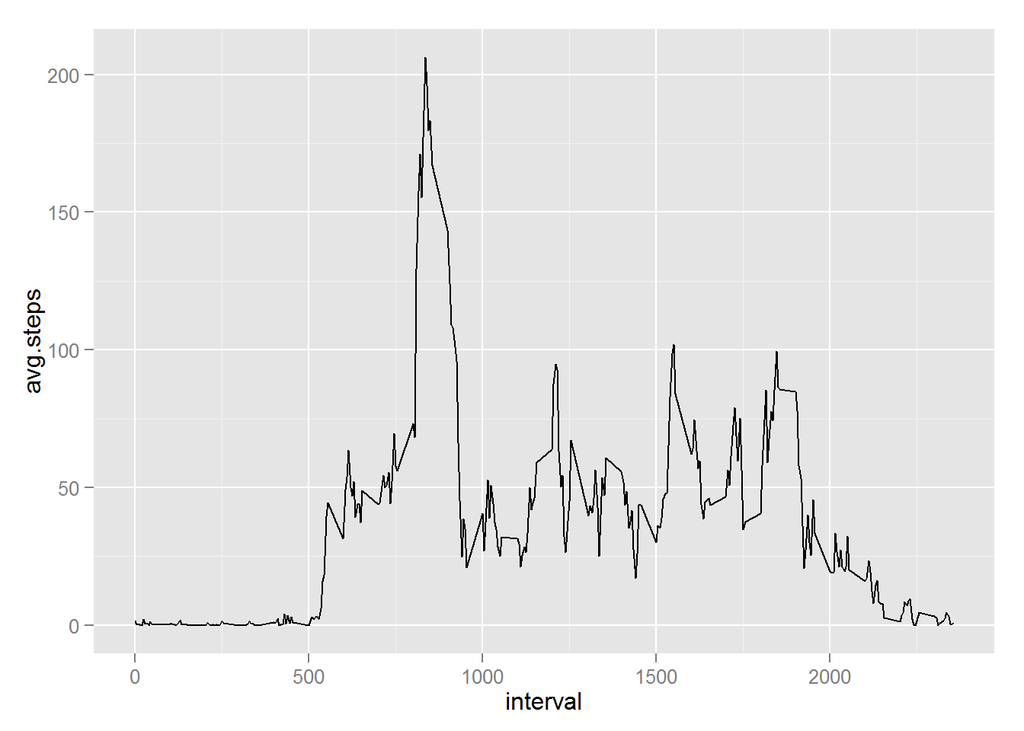

```r
library(plyr)
avginterval<-ddply(act.na, "interval", summarise, avg.steps=mean(steps))
qplot(interval, avg.steps, data=avginterval, geom="line")
```

*2. Which 5-minute interval, on average across all the days in the dataset, contains the maximum number of steps?*

```r
max<-max(avginterval$avg.steps)
avginterval[avginterval$avg.steps==max,]
```

```
##     interval avg.steps
## 104      835     206.2
```

- The 5-minute interval with the maximum number of steps is interval # 835.